# Taller 1 - Análisis avanzado de datos

Carlos Garavito

# Problema

El conjunto de datos `taller1.txt` contiene la información del perfil genómico de un conjunto de 1200 líneas celulares. Para estas se busca determinar cuáles de los 5000 genes (ubicados en cada columna) son de relevancia para la predicción de la variable respuesta (efectividad del tratamiento anticancer, medida como variable continua).

Instalando las librerias necesarias para trabajar en el ambiente de trabajo, se ejecuta el siguiente código:

```r
#install.packages("tidyverse")
#install.packages("ggcorrplot")
#install.packages("glmnet")
#install.packages("dplyr")
```

```r
library("tidyverse")
library("ggcorrplot")
library("glmnet")
library("dplyr")
```

Cargando el conjunto de datos e imprimiendo una muestra se encuentra:

```r
PATH_CWD <- getwd()
setwd(PATH_CWD)

my_data <- read.delim("taller1.txt", sep = ",")
my_data <- as_tibble(scale(my_data, scale = TRUE, center = TRUE )) # scala y centra los valores de las variables para hacerlos comparables

head(my_data)
```

| y | V1 | V2 | V3 | V4 | V5 | V6 | V7 | V8 | V9 | V10 | V11 | V12 | V13 | V14 | V15 | V16 | V17 | V18 | V19 | V20 | V21 | V22 | V23 | V24 | V25 | V26 | V27 | V28 | V29 | … |
| --- | --- | --- | --- | --- | --- | --- | --- | --- | --- | --- | --- | --- | --- | --- | --- | --- | --- | --- | --- | --- | --- | --- | --- | --- | --- | --- | --- | --- | --- | --- |
| -0.4601775 | -0.58454123 | 0.6279107 | -0.4825310 | -0.1971342 | -0.65126063 | -0.6809905 | 0.8926908 | 0.5318312 | -1.2011825 | -0.6523997 | -0.1233890 | -1.5758368 | -0.4348279 | -0.009331009 | 0.33837335 | 0.2921374 | 0.845479551 | -0.03799684 | 1.8056284 | -1.61128511 | -0.77928467 | -0.9225520 | 0.98892885 | 1.4505235 | 0.4786766 | -0.20045207 | -0.8072849 | -0.04507787 | -0.4121891 | … |
| -0.7450755 | -0.25297897 | -0.7752347 | -0.5303860 | 1.2314962 | 0.09250248 | 1.0375710 | 0.3309654 | -0.7046530 | -0.3811770 | -0.5290377 | 0.8178452 | -0.2734630 | -0.9132406 | 0.252797554 | 0.33431829 | -1.5791523 | -1.279920275 | -0.57506923 | 1.3778269 | -1.21058058 | 1.36046395 | -0.3210207 | -0.69093039 | 1.7612832 | -1.0426508 | 0.25794923 | 2.2375705 | -0.41343551 | 0.3733011 | … |
| 0.7012029 | 1.54275321 | 0.8639224 | -0.5863068 | 0.2536981 | -1.58345737 | -0.6744202 | 0.1608781 | 1.0660174 | -1.4892219 | 0.9181790 | -1.1482225 | -0.1092332 | -0.4072544 | 1.894749463 | 0.08935546 | -0.3039677 | 0.005291289 | 1.26884468 | 1.5489869 | -0.01749475 | -0.00246413 | -0.3646716 | 0.55562346 | -0.6499477 | 0.7306552 | -0.55023062 | -1.5470587 | -0.91711331 | -0.2511484 | … |
| -0.2787541 | 0.04885769 | -0.7654752 | -0.4116225 | -0.4898628 | -0.05729279 | -0.0772063 | -0.4378193 | -1.2399714 | -0.2994853 | 0.9440330 | 0.4515634 | -1.4716957 | 0.6960082 | -1.038056049 | 0.84156966 | -1.2046242 | 0.130293156 | 0.29639016 | 0.1720575 | 1.46550161 | -0.86142543 | 1.7571697 | 0.85165922 | 0.4907080 | 1.3323377 | -1.20040957 | 0.7994698 | -1.49907627 | -2.1948178 | … |
| 1.5025310 | 0.10786199 | 0.6384950 | 0.7009645 | 0.6571906 | -0.05336738 | 0.6396879 | -1.1742305 | 2.0684476 | -0.5713861 | 0.7465286 | 0.2399975 | 0.2303968 | 0.1797628 | 2.117146829 | -0.18100915 | -0.7574308 | -0.721826494 | 0.54517968 | -0.1268622 | 0.80408214 | -1.04776610 | -0.2725700 | -1.38736492 | -0.6403537 | 0.6165428 | 0.90990383 | -0.7997065 | 0.11958332 | 1.2091344 | … |
| 1.2219734 | 1.69970829 | 1.1136485 | 0.2515271 | 0.9879978 | -0.29657711 | -0.5885769 | -0.2965767 | -0.1544347 | 0.1559754 | 0.8961215 | 0.9764552 | 0.4511945 | -1.8270402 | 0.522718885 | 0.26381551 | 0.1026503 | -0.840930684 | 2.03085463 | -0.1396336 | 1.15216216 | 1.52622242 | -0.8552482 | -0.07623554 | -0.9777064 | 0.9429560 | -0.02048538 | -1.7000717 | 0.22946522 | -0.6216969 | … |

Identificando la cantidad de filas y columnas, se obtiene:

```r
print(paste0("Número de filas:  ", dim(my_data)[1], "; ", "Número de columnas: ", dim(my_data)[2]))
```

```
## [1] "Número de filas:  1200; Número de columnas: 5001"
```

## ¿Hay multicolinealidad en los datos?

Si, observe que el conjunto de datos tiene un mayor número de columnas que número de filas. En este escenario, la regresión lineal puede carecer de una solución unica. Este es un problema conocido como “La maldición de la dimensionalidad”, el cual establece que el número de variables predictoras puede incrementar de forma exponencial [1] y esto a su vez implica que éstas estén altamente correlacionadas entre sí [2]. Para tratar este tipo de problemas de alta dimensionalidad, se recomienda el uso de técnicas que justamente reduzcan la dimensionalidad del problema, como es el caso de PCA. Otra alternativa, qué es la que se abordará en el desarrollo de este ejercicio, es la de implementar técnicas de regularización como Lasso o Ridge, las cuales penalizan los terminos del modelo de regresión para atacar el problema de alta dimensionalidad.

## Dividir los datos en entrenamiento y prueba

Generando las variables `X`e `y` y realiando la partición tal que se tengan los conjuntos de datos:

- Entrenamiento: 1000 lineas celulares,
- Prueba: 200 lineas celulares,

se tiene:

```r
set.seed(456)

X <- my_data %>% select(-y)
y <- my_data %>% select(y)

sample_size <- nrow(X)

train <- sample(sample_size, 1000)
test <- sample(sample_size)[!seq(sample_size) %in% train]

x_train <- X[train,]
y_train <- y[train,]

x_test <- X[test,]
y_test <- y[test,]
```

```r
cat(paste0("Número de filas ´x_train´:  ", nrow(x_train), "; ",
           "Número de columnas ´x_train´: ", dim(x_train)[2],"; ", "\n",
           "Número de filas ´x_test´: ", nrow(x_test),"; ",
           "Número de columnas ´x_test´: ", dim(x_test)[2],"; ", "\n",

           "Número de filas ´y_test´: ", nrow(y_test),"; ",
           "Número de columnas ´y_test´: ", dim(y_test)[2]
           ))
```

```
## Número de filas ´x_train´:  1000; Número de columnas ´x_train´: 5000;
## Número de filas ´x_test´: 200; Número de columnas ´x_test´: 5000;
## Número de filas ´y_test´: 200; Número de columnas ´y_test´: 1
```

## Determinando los valores de $\lambda_r$ y $\lambda_l$

Para la estimación de $\lambda_r$, se tiene:

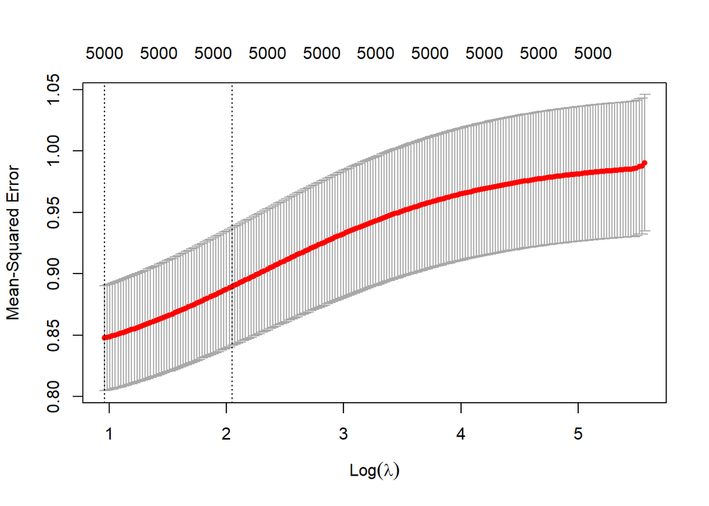

```r
fit_ridge <- cv.glmnet(x=as.matrix(x_train), y=unlist(y_train), type.measure="mse", alpha=0, nlambda=200, nfolds=10)
plot(fit_ridge)
```

Se obtiene que el mejor valor de $\lambda_r$ es,

```r
fit_ridge$lambda.1se
```

```
## [1] 7.75471
```

De manera análoga, la estimación de $\lambda_l$, se tiene:

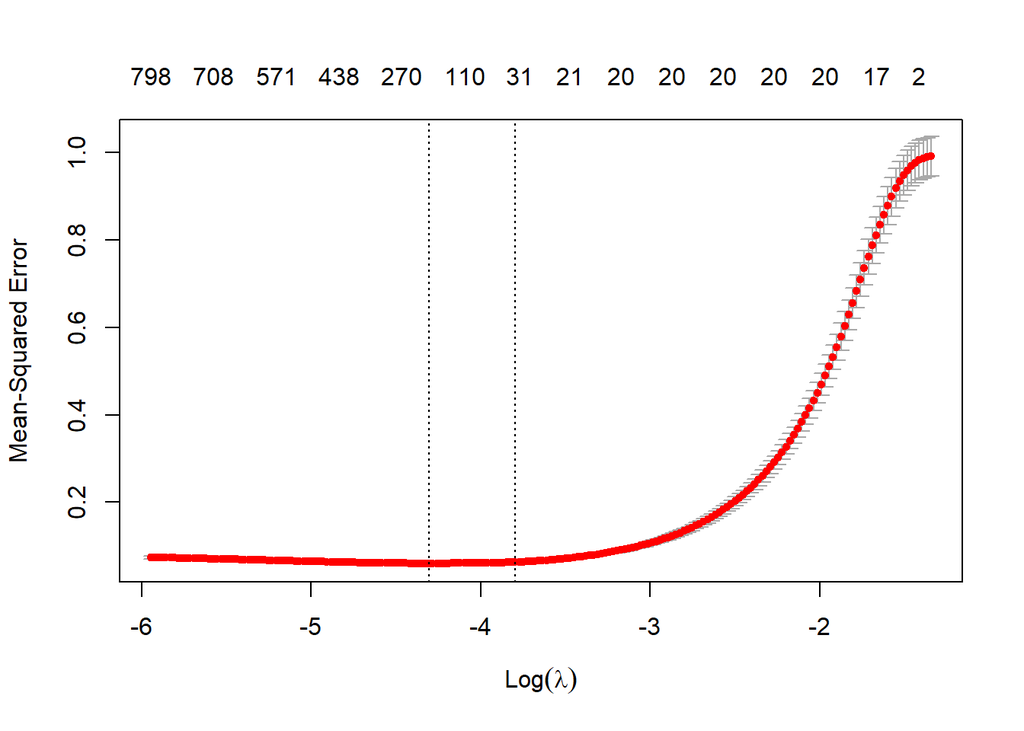

```r
fit_lasso <- cv.glmnet(x=as.matrix(x_train), y=unlist(y_train), type.measure="mse", alpha=1, nlambda=200, nfolds=10)
plot(fit_lasso)
```

Se obtiene que el mejor valor de $\lambda_l$ es,

```r
fit_lasso$lambda.1se
```

```
## [1] 0.02248418
```

## Ajuste la regresión ridge y lasso con los valores estimados de $\lambda_r$ y $\lambda_l$ obtenidos en (3) usando los 1000 datos de entrenamiento.

Ajustando ridge,

```r
best_lambda_ridge <- fit_ridge$lambda.1se
fit_ridge_best <- glmnet(as.matrix(x_train), unlist(y_train), alpha=0, lambda=best_lambda_ridge)
```

Ajustando lasso,

```r
best_lambda_lasso <- fit_lasso$lambda.1se
fit_lasso_best <- glmnet(as.matrix(x_train), unlist(y_train), alpha=1, lambda=best_lambda_lasso)
```

## Con base a los resultados anteriores, determine el más apropiado para propósitos de predicción. Considere unicamente el ECM en los 200 datos de prueba para su decisión.

Evaluando ridge para el conjunto de datos de prueba,

```r
fit_ridge_best.predicted <- predict(fit_ridge_best, newx= as.matrix(x_test))
mean((unlist(y_test) - fit_ridge_best.predicted)^2)
```

[output not shown]

Evaluando lasso,

```r
fit_lasso_best.predicted <- predict(fit_lasso_best, newx= as.matrix(x_test))
mean((unlist(y_test) - fit_lasso_best.predicted)^2)
```

```
## [1] 0.06184942
```

Se observa que el mejor modelo para propósitos de predicción, es la regresión lasso ya que tiene el menor ECM.

## Ajuste el modelo seleccionado en (5) para los 1200 datos. Note que en este punto ya tiene un $\lambda$ estimado y un modelo seleccionado.

Ajustando el modelo con todos los datos, se tiene:

```r
fit_lasso_best_full <- glmnet(as.matrix(X), unlist(y), alpha=1, lambda=best_lambda_lasso)
```

## Grafique las trazas de los coeficientes en función de la penalización para el modelo ajustado

Observe que los coeficientes de las variables que son relevantes en el proceso de regularización lasso, son:

```r
coef <- predict(fit_lasso_best_full, newx = as.matrix(X), type = 'coefficients')
df_coef <- as.data.frame(as.matrix(coef))
df_coef <- df_coef %>% arrange(desc(s0))
df_coef$var <- row.names(df_coef)
df_coef <- df_coef[df_coef$s0 != 0,]
df_coef
```

|  | s0 | var |
| --- | --- | --- |
| V11 | 2.103507e-01 | V11 |
| V17 | 2.102439e-01 | V17 |
| V7 | 2.059587e-01 | V7 |
| V18 | 2.059239e-01 | V18 |
| V5 | 2.055179e-01 | V5 |
| V15 | 2.037647e-01 | V15 |
| V6 | 2.023649e-01 | V6 |
| V19 | 2.013210e-01 | V19 |
| V10 | 1.989793e-01 | V10 |
| V14 | 1.988857e-01 | V14 |

[output cut: 17 more lines]

Así, generando el grafico de trazas para este conjunto específico de variables, se obtiene:

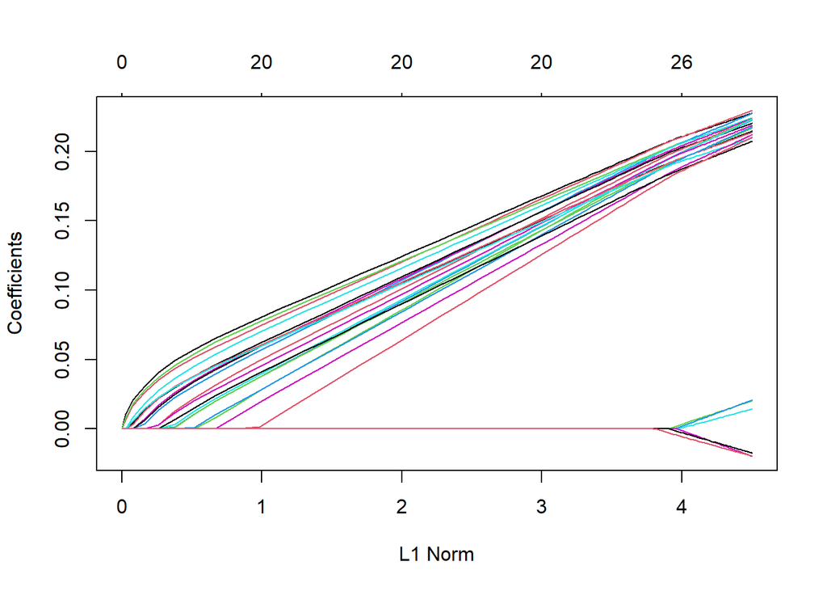

```r
list_var <- df_coef$var
index_to_remove <- grep("(Intercept)", list_var)
list_var <- list_var[-index_to_remove]
x_modified = X %>% select(all_of(list_var))
fit_lasso_best.predicted.trace_plot <- glmnet(x=as.matrix(x_modified), y=unlist(y), type.measure="mse", alpha=1, nlambda=200)
plot(fit_lasso_best.predicted.trace_plot)
```

## Resultados obtenidos dado el objetivo inicial del estudio

Bajo un modelo de regresión regularizada lasso, se observa que las variables que son relevantes para la predicción en la efectividad del tratamiento anticancer son las siguientes:

```r
list_var
```

```
##  [1] "V11"   "V17"   "V7"    "V18"   "V5"    "V15"   "V6"    "V19"   "V10"
## [10] "V14"   "V2"    "V3"    "V16"   "V20"   "V4"    "V8"    "V12"   "V1"
## [19] "V9"    "V13"   "V1293" "V1828" "V3763" "V3917" "V3684" "V220"
```

A su vez, en el grafico de barras se puede apreciar cuales de ellas son mas significativas.

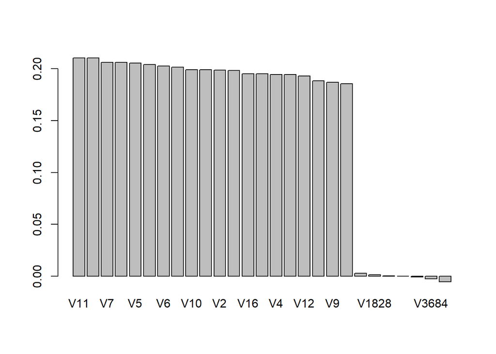

```r
barplot(df_coef$s0, names.arg=df_coef$var,)
```

Además, es posible dar cuenta que, dado el escenario de alta dimensionalidad y que existen mas variables que registros, los modelos de regresión regularizados son capaces de predecir la variable objetivo, en particular, se encuentra que entre los modelos de regresión ridge y lasso, el que mejor aproxima es lasso.

## References

[1]

Trevor Hastie, Robert Tibshirani, Jerome Friedman, The elements of statistical learning, Springer Series in Statistics, 2009.

[2]

Andy Field, Jeremy Miles, and Zoe Field, Discovering statistics using r, SAGE Publications, 2012.